# data_visualizations

Elisabeth Nesmith

12/11/2021

```r
library(data.table)
library(tidyverse)
# load in hms_data_new
hms_data <- read_csv("Data/hms_data_new.csv")
# convert variables to factors
factors <- c(4:25)

hms_data[, 4:25] <- lapply(hms_data[,factors], factor)
```

# Academic Impact Visualizations

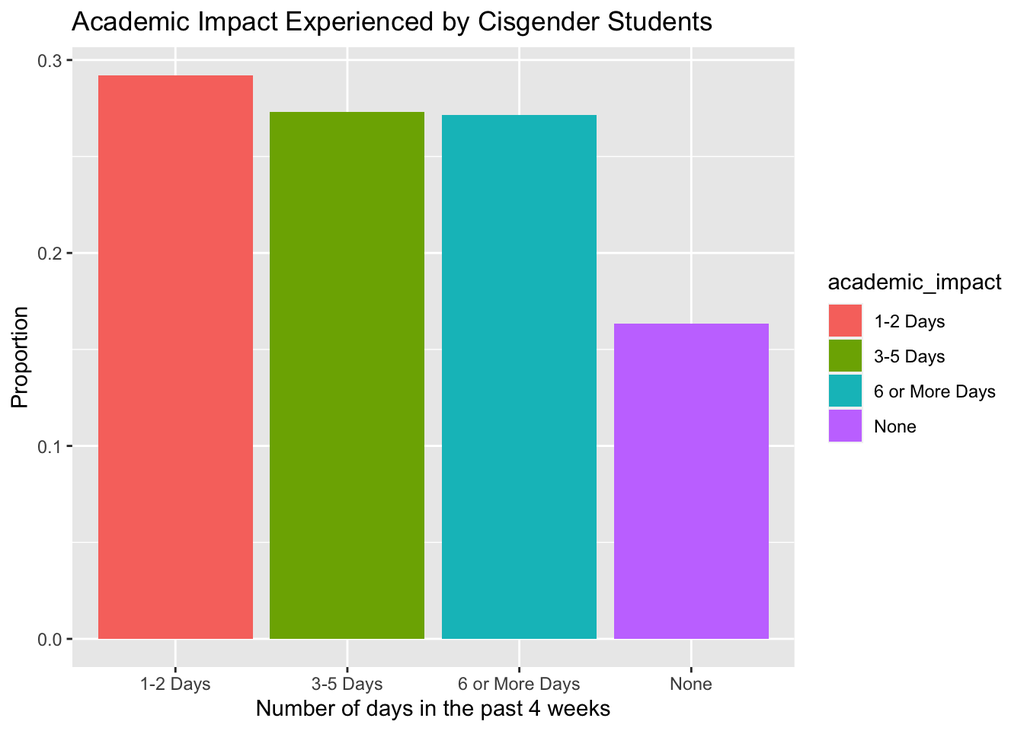

```r
# bar graph of cis students and academic impact - In the past 4 weeks, how many days have you felt that emotional or mental difficulties have hurt your academic performance?

# 1 - None
# 2 - 1-2 Days
# 3 - 3-5 Days
# 4 - 6 or more days

# create text variable of aca_impa
hms_data %>%
  mutate(academic_impact = as.factor(ifelse(aca_impa == 1, "None",
                                ifelse(aca_impa == 2, "1-2 Days",
                                      ifelse(aca_impa == 3, "3-5 Days", "6 or More Days"))))) %>%
  filter(cis == 1) %>%
  ggplot(aes(x = academic_impact, fill = academic_impact)) +
    geom_bar(aes(y = (..count..)/sum(..count..))) +
    labs(title = "Academic Impact Experienced by Cisgender Students", x = "Number of days in the past 4 weeks", y = "Proportion")
```

Approximately 29% of cisgender students indicated that they had one to two days in the past month when they felt their academic performance was harmed by emotional or mental difficulties. 16% of students did not have any days when they felt this way, while approximately 27% had experienced each of 3-5 or 6 or more days of this.

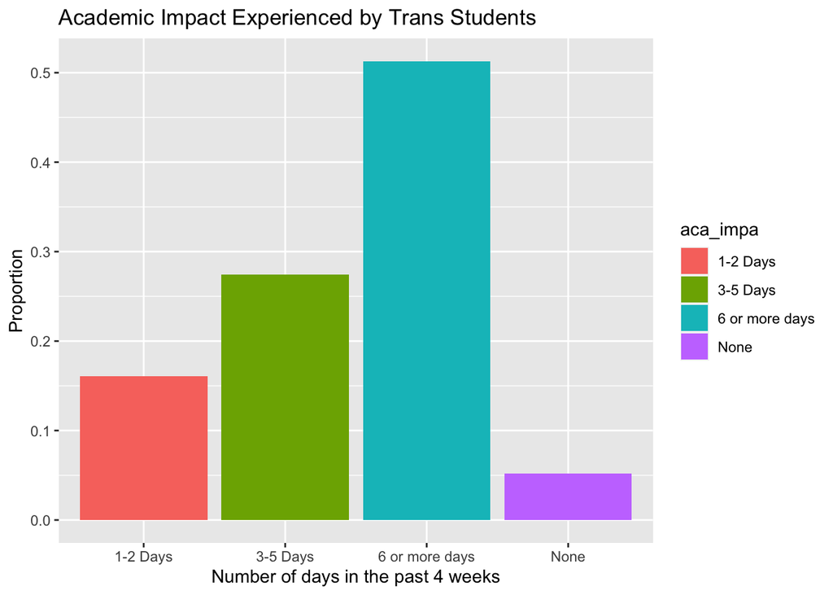

```r
# bar graph of trans students and academic impact
hms_data %>%
  mutate(aca_impa = ifelse(aca_impa == 1, "None",
                           ifelse(aca_impa == 2, "1-2 Days",
                                  ifelse(aca_impa == 3, "3-5 Days", "6 or more days")))) %>%
  filter(trans == 1) %>%
  ggplot(aes(x = aca_impa, fill = aca_impa)) +
    geom_bar(aes(y = (..count..)/sum(..count..))) +
    labs(title = "Academic Impact Experienced by Trans Students", x = "Number of days in the past 4 weeks", y = "Proportion")
```

The majority of trans students (~52%) reported that they felt their academic performance suffered from emotional and mental difficulties 6 or more days of the past month. 27% reported feeling this way 3-5 days, 16% 1-2 days, and only about 5% did not feel this way at all.

# Sense of Belonging Visualizations

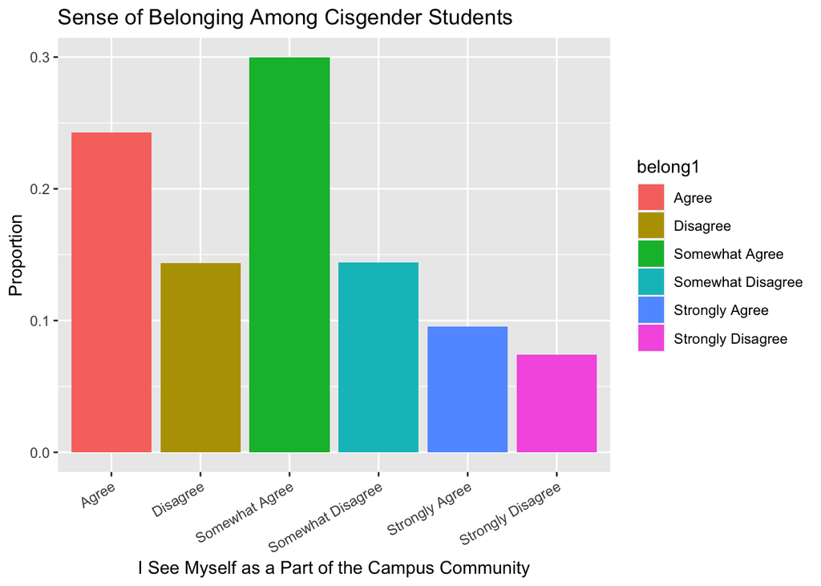

```r
# bar graph of cis students and sense of belonging - How much do you agree with the following statement?: I see myself as a part of the campus community.

# 1 - Strongly Agree
# 2 - Agree
# 3 - Somewhat Agree
# 4 - Somewhat Disagree
# 5 - Disagree
# 6 - Strongly Disagree

hms_data %>%
  mutate(belong1 = ifelse(belong1 == 1, "Strongly Agree",
                           ifelse(belong1 == 2, "Agree",
                                  ifelse(belong1 == 3, "Somewhat Agree",
                                         ifelse(belong1 == 4, "Somewhat Disagree",
                                                ifelse(belong1 == 5, "Disagree", "Strongly Disagree")))))) %>%
  filter(cis == 1) %>%
  ggplot(aes(x = belong1, fill = belong1)) +
    geom_bar(aes(y = (..count..)/sum(..count..))) +
    labs(title = "Sense of Belonging Among Cisgender Students", x = "I See Myself as a Part of the Campus Community", y = "Proportion") +
    theme(axis.text.x = element_text(angle = 30, vjust = 1, hjust=1))
```

30% of cisgender students somewhat agree that they see themselves as part of the campus community. Next highest, about 24% of students agree. The lowest category, strongly disagree, is only about 7% of students.

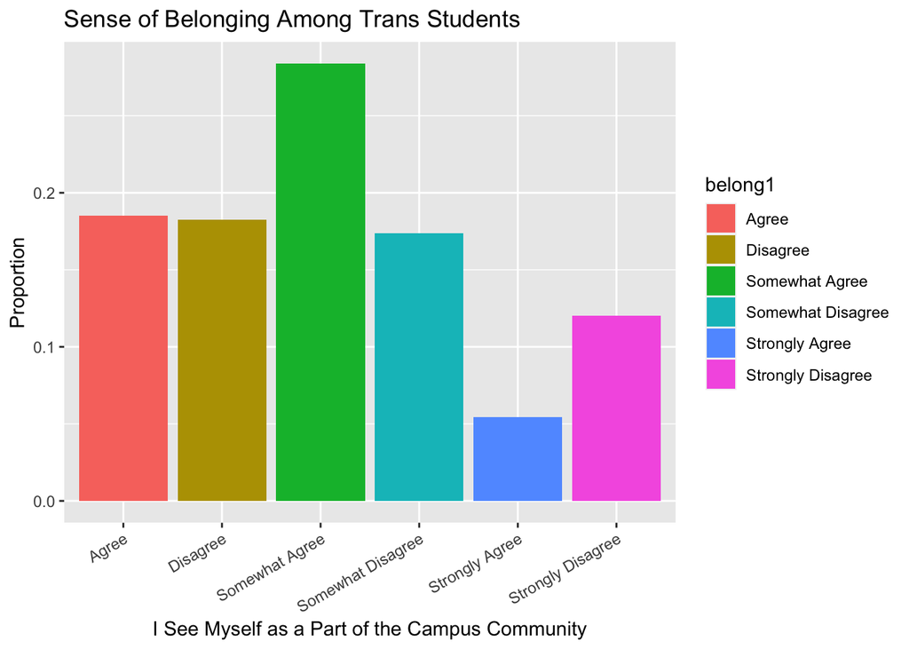

```r
hms_data %>%
  mutate(belong1 = ifelse(belong1 == 1, "Strongly Agree",
                           ifelse(belong1 == 2, "Agree",
                                  ifelse(belong1 == 3, "Somewhat Agree",
                                         ifelse(belong1 == 4, "Somewhat Disagree",
                                                ifelse(belong1 == 5, "Disagree", "Strongly Disagree")))))) %>%
  filter(trans == 1) %>%
  ggplot(aes(x = belong1, fill = belong1)) +
    geom_bar(aes(y = (..count..)/sum(..count..))) +
    labs(title = "Sense of Belonging Among Trans Students", x = "I See Myself as a Part of the Campus Community", y = "Proportion") +
    theme(axis.text.x = element_text(angle = 30, vjust = 1, hjust=1))
```

# Discrimination Visualizations

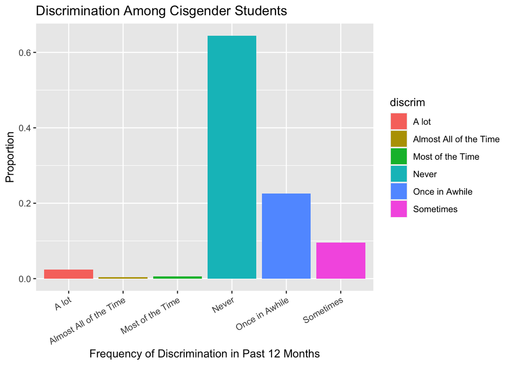

```r
# bar graph of cis students and discrimination - In the past 12 months, how many times have you been treated unfairly because of your race, ethnicity, gender, sexual orientation, or cultural background?

# 1 - Never
# 2 - Once in Awhile
# 3 - Sometimes
# 4 - A lot
# 5 - Most of the Time
# 6 - Almost All of the Time

hms_data %>%
  mutate(discrim = ifelse(discrim == 1, "Never",
                           ifelse(discrim == 2, "Once in Awhile",
                                  ifelse(discrim == 3, "Sometimes",
                                         ifelse(discrim == 4, "A lot",
                                                ifelse(discrim == 5, "Most of the Time", "Almost All of the Time")))))) %>%
  filter(cis == 1) %>%
  ggplot(aes(x = discrim, fill = discrim)) +
    geom_bar(aes(y = (..count..)/sum(..count..))) +
    labs(title = "Discrimination Among Cisgender Students", x = "Frequency of Discrimination in Past 12 Months", y = "Proportion") +
    theme(axis.text.x = element_text(angle = 30, vjust = 1, hjust=1))
```

65% of cisgender students did not experience discrimination in the past year.

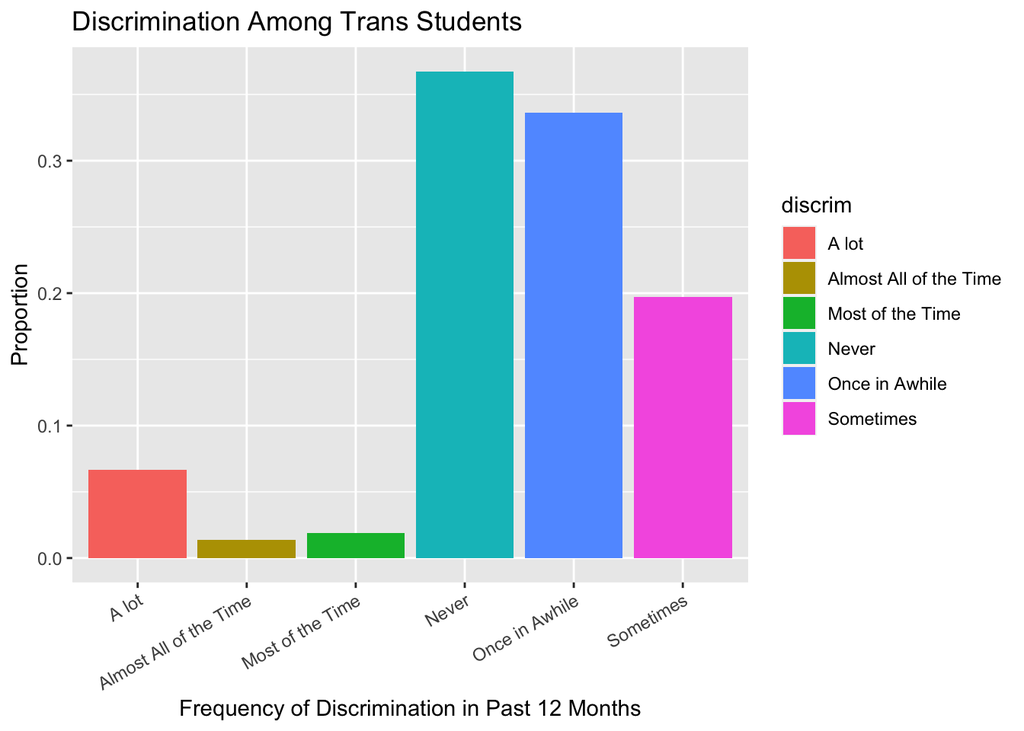

```r
# bar graph of trans students and discrimination

hms_data %>%
  mutate(discrim = ifelse(discrim == 1, "Never",
                           ifelse(discrim == 2, "Once in Awhile",
                                  ifelse(discrim == 3, "Sometimes",
                                         ifelse(discrim == 4, "A lot",
                                                ifelse(discrim == 5, "Most of the Time", "Almost All of the Time")))))) %>%
  filter(trans == 1) %>%
  ggplot(aes(x = discrim, fill = discrim)) +
    geom_bar(aes(y = (..count..)/sum(..count..))) +
    labs(title = "Discrimination Among Trans Students", x = "Frequency of Discrimination in Past 12 Months", y = "Proportion") +
    theme(axis.text.x = element_text(angle = 30, vjust = 1, hjust=1))
```

Only 37% of trans students did not experience discrimination at all in the past year.